# Sociología del Género

SOL3061 | Clase 4. Nivel macro: instituciones

Tania Hutt

## Nivel macro: instituciones

[figure not shown]

## Instituciones generizadas

- Además de ser un conjunto de ideas y algo que uno “hace”, el género también es un **principio organizador** que permea nuestras instituciones sociales.
- Las creencias e ideas de género que afectan nuestros ambientes ejercen una influencia en nuestras vidas **independiente** de nuestras propias creencias, personalidades e interacciones.
- El género permea en las **normas** (creencias y prácticas conocidas y seguidas ampliamente) y **políticas** (expectativas y reglas explícitas y codificadas) institucionales.

## *Gendered institutions*

- El género se usa como principio organizador, por ejemplo, **canalizando** a hombres y mujeres hacia diferentes espacios o actividades, que son **valorados de manera diferente**.
- Qué tan saliente es el género varía a través de las diferentes partes, espacios y actividades de la institución.

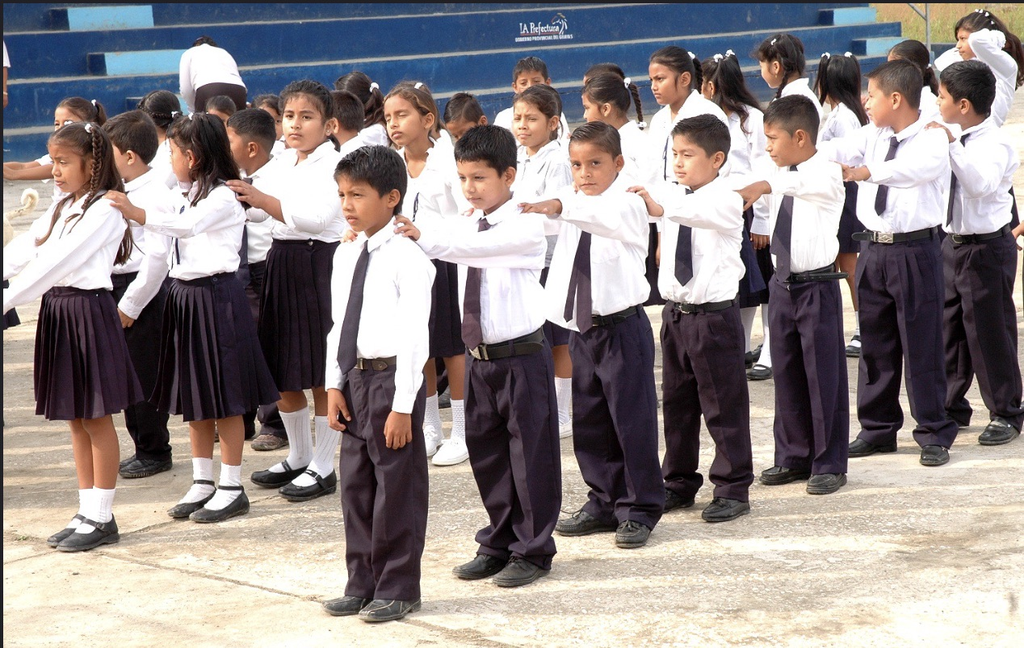

## Sexismo estructural

- Las instituciones generizadas afirman y refuerzan tanto las **diferencias** como la **desigualdad** de género, de manera interseccional.
- Resulta en **desigualdades institucionalizadas**: producidas y reproducidas por el funcionamiento rutinario de las instituciones.
- ¿Ejemplo de Crocco-Valdivia y Galaz-Valderrama (2023) sobre universidades generizadas?

# Organizaciones generizadas

## Organizaciones generizadas

(Acker 1990)

- Antes de Acker, las organizaciones se entendían como **neutras** respecto del género.
- El género está en la **lógica organizacional**: reglas, descripciones de cargo, escalas de salario, evaluaciones.
- El trabajo “abstracto” supone un **trabajador universal**: hombre, dedicado por completo, sin responsabilidades de cuidado.

“The concept of a universal worker excludes and marginalizes women who cannot, almost by definition, achieve the qualities of a real worker because to do so is to become a man” (Acker 1990, 150).

## Género en cinco procesos organizacionales

(Acker 1990)

1. **Divisiones de género:** tipo de trabajo, comportamientos permitidos, uso del espacio, distribución del poder.
2. **Símbolos e imágenes** que explican, refuerzan o se oponen a esas divisiones.
3. **Interacciones** de dominio y sumisión.
4. **Presentación de sí**: lenguaje, ropa.
5. **Lógica organizacional**: reglas, contratos, evaluaciones de desempeño.

## Baños públicos

**¿Qué revela el diseño y la regulación de los baños públicos sobre el género como principio organizador?**

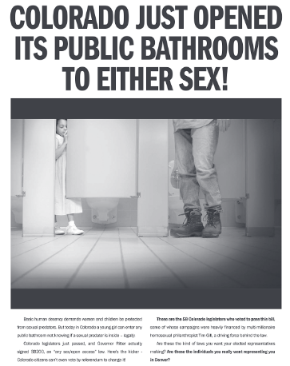

[figure not shown]

[figure not shown]

## Baños y “penis panics”

(Schilt & Westbrook 2015)

- Foco solo en baños **de mujeres**, no en baños de hombres.
- El problema son los **genitales**, no la identidad.
- Supuesto heterosexual: los baños como zonas “libres de sexualidad”.
- Mujeres como **débiles** que necesitan protección; personas trans como merecedoras de **menos** protección.

## De “hacer” a “determinar” género

(Westbrook & Schilt 2014)

- **Determinar género:** prácticas mediante las cuales *otras personas e instituciones* ubican a alguien en una categoría de género.
- Dos ideologías en tensión: **basada en la biología** (innata e inmutable) y **basada en la identidad** (si otros validan el reclamo).
- Casos: leyes de derechos laborales trans, cambio de sexo registral, atletas trans.

## Los criterios varían según el espacio

(Westbrook & Schilt 2014)

| Tipo de espacio | Criterio dominante | Ejemplos |
| --- | --- | --- |
| **No sexual, integrado** | Identidad | Lugares de trabajo |
| **No sexual, segregado** | Identidad + cuerpo | Baños, camarines, deporte |
| **Sexual** | Biología (genitales) | Relaciones sexuales |

- **Pánicos de género** y **trabajo de naturalización** restituyen el binario.
- Los espacios de mujeres se vigilan más: desigualdad **bajo la apariencia de protección**.

# Regímenes de desigualdad

## De organizaciones generizadas a regímenes de desigualdad

(Acker 2006)

**Regímenes de desigualdad:** “loosely interrelated practices, processes, actions, and meanings that result in and maintain class, gender, and racial inequalities within particular organizations” (p. 443).

- Dos preguntas: ¿cómo estudiar la **interseccionalidad**? ¿Por qué **fracasan** los esfuerzos por la igualdad en las organizaciones?
- Los regímenes están **vinculados con la sociedad**: su política, historia y cultura.
- La organización es el lugar donde la estructura macro **se vuelve práctica concreta**.

## Componentes de un régimen de desigualdad

(Acker 2006, pp. 444–455)

**1. Bases**

Clase, género y raza. “‘Class equality’ is an oxymoron” (p. 444).

**2. Forma y grado**

Jerarquía, segregación, brechas. La segregación se **reconfigura**.

**3. Procesos**

Prácticas cotidianas que producen desigualdad.

**4. Visibilidad**

Quienes dominan ven la desigualdad “en otro lado”.

**5. Legitimidad**

Cuán justificada parece la desigualdad.

**6. Control**

Directo, indirecto e internalizado.

## Procesos que producen desigualdad

(Acker 2006)

- **Requisitos del trabajo:** organizado según “the image of a white man who is totally dedicated to the work” (p. 448).
- **Jerarquías de clase:** sistemas de clasificación de cargos que hacen la jerarquía intocable.
- **Reclutamiento y contratación:** “‘Competence’ involves judgment” (p. 450).
- **Fijación salarial:** los salarios individualizados producen desigualdad.
- **Interacciones informales:** exclusión de reuniones y salidas después del trabajo.

## Visibilidad, legitimidad y control

(Acker 2006)

- **Visibilidad:** “People in dominant groups generally see inequality as existing somewhere else, not where they are” (p. 452).
- **Legitimidad:** “Gender and race processes are more legitimate when embedded in legitimate class processes” (p. 453).
- **Control:** también internalizado, como la creencia de que no tiene sentido desafiar el orden de las cosas.

“High visibility and low legitimacy of inequalities may enhance the possibilities for change” (p. 454).

## ¿Pueden cambiar los regímenes?

(Acker 2006, pp. 455–460)

- El cambio exitoso combina **movimientos sociales y legislación** con **aliados internos**, y a menudo coerción.
- Contradicción: reducir la desigualdad se opone a algunos **objetivos de las organizaciones**.
- Las políticas de conciliación “may reinforce, not undermine, the male model of organizing” (p. 457).

## Lógica de género en evaluaciones

(Correll et al. 2020)

- Gran empresa tecnológica de Silicon Valley.
- Evaluaciones de desempeño de **208 trabajadores**, hechas por sus gerentes: texto completo y puntaje (1 a 5), con 88 códigos de lenguaje.
- Dos tipos de lenguaje:
  - **Colaborativo:** comunal, personalidad positiva, perspectiva de equipo, trabajo de servicio.
  - **“Hacerse cargo”:** agencia, visión, líder, genio, visionario, comunicación asertiva.

(Correll et al. 2020)

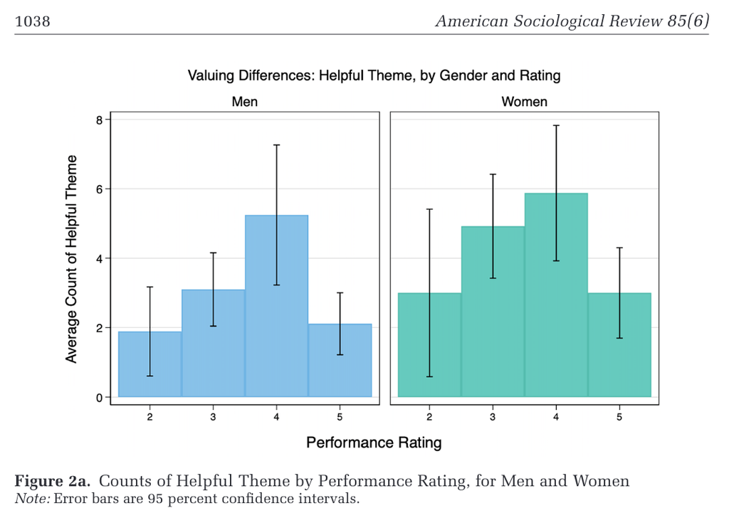

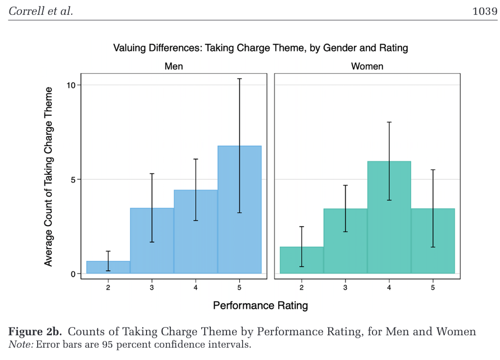

## La universidad como organización generizada

(Crocco-Valdivia & Galaz-Valderrama 2023)

- Revisión sistemática de **32 estudios** empíricos (2015–2020) sobre el trabajo de las académicas.
- Las académicas están sobrerrepresentadas en **gestión y docencia**, menos valoradas que la **investigación**.
- El **trabajo de cuidados** se replica en la universidad, con estudiantes y con colegas.
- El **capitalismo académico** (productividad individual, competencia) profundiza esa desigualdad.

## Perspectiva de género en las políticas organizacionales

[figure not shown]

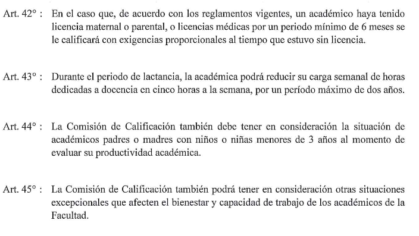

**¿Estas políticas desafían o refuerzan el modelo masculino de organización?** (Acker 2006)

# El contexto nacional: políticas de familia

## Antecedente: el contexto nacional importa

(Hook 2006)

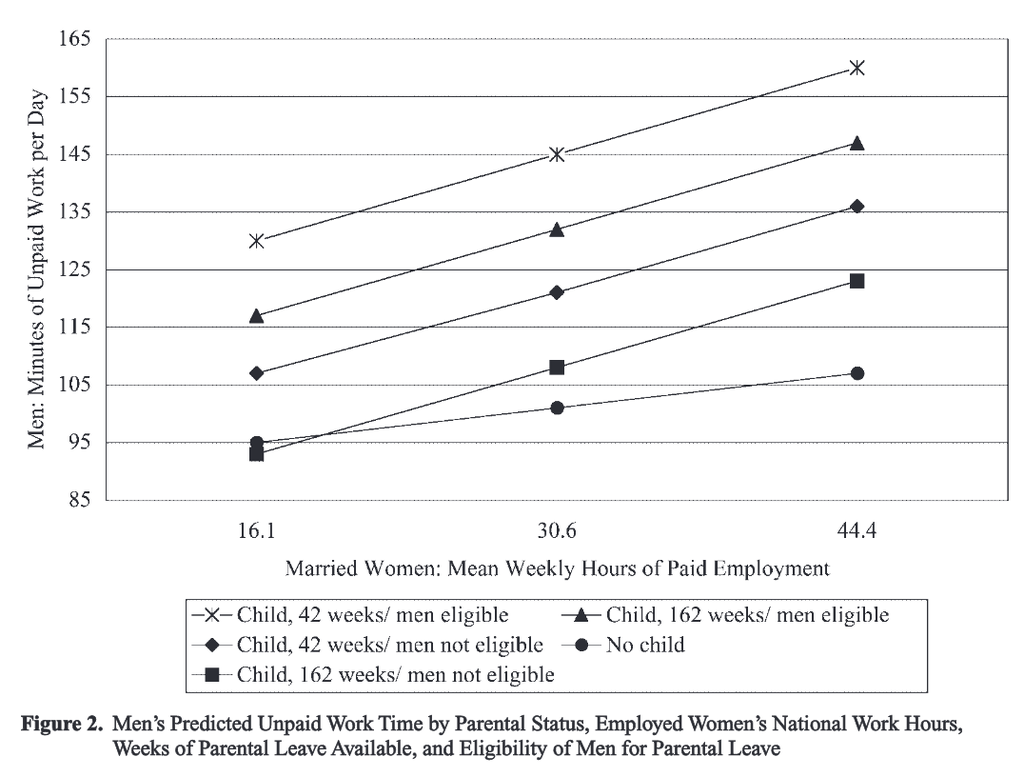

## Políticas de familia y empleo de las madres

(Hook & Paek 2020)

- Dos políticas: **cuidado y educación temprana** (facilita el empleo) y **licencias parentales** (lo reduce si son largas).
- ¿Afectan igual a todas las madres y en todos los países?
- Factor clave: la **desigualdad salarial** del país.
- 23 países, 1999–2016, **1,2 millones de madres** de niños pequeños.

## Hallazgos de Hook y Paek (2020)

- El gasto en **cuidado temprano** aumenta el empleo, sobre todo de madres **sin educación universitaria** en países **desiguales**.
- Las licencias de **más de seis meses** reducen el empleo, sobre todo de madres **con educación universitaria**.
- La desigualdad **empuja** al empleo a las madres con menos educación.

La misma política tiene efectos distintos según la **clase** y la **desigualdad** del país: el nivel macro es interseccional.

(Hook & Paek 2020, Figura 4)

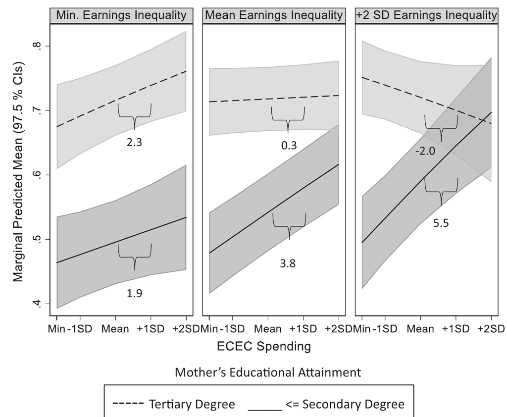

[figure not shown]

## Efectos de la legalización del aborto en EE.UU.

(Myers & Welch 2021; actualizado)

- Menos nacimientos (−4% a −11%) y menos maternidad adolescente (−34%).
- Reducción de 30–50% en la mortalidad materna de mujeres no blancas.
- Más educación, participación laboral, prestigio ocupacional e ingresos, sobre todo de mujeres afroamericanas.
- Ser rechazada al solicitar un aborto aumenta la deuda vencida (+78%) y los desalojos, quiebras y juicios (+81%).

## Evidencia reciente: después de *Dobbs* y en América Latina

- Las prohibiciones post-*Dobbs* aumentaron los nacimientos **2,3%** (Dench, Pineda-Torres & Myers 2024).
- La mortalidad infantil fue **5,6%** mayor de lo esperado en estados con prohibición; **11%** en bebés afroamericanos (Gemmill et al. 2025).
- Ciudad de México (2007): la legalización redujo la **morbilidad materna** (Clarke & Mühlrad 2021).
- Uruguay (2012): evidencia **mixta** sobre la fecundidad adolescente.

## Discusión liderada por Candela y Trajan

[figure not shown]